# Can I Predict Your Income?

Yifan Yang

5/18/2018

## Can I predict your income

I was genuinely curious about the relation between people’s backgrounds and their income. And I happened to found the data about the population in [American Fact Founder](https://factfinder.census.gov/faces/nav/jsf/pages/index.xhtml). So I searched for the sampled data in population which can be find [here](https://factfinder.census.gov/faces/tableservices/jsf/pages/productview.xhtml?pid=ACS_pums_csv_2012_2016&prodType=document). The data I am using for prediction is [2012-2016 Alaska Population Records](https://www2.census.gov/programs-surveys/acs/data/pums/2016/5-Year/csv_pak.zip), because there are less people so my computer won’t cry. I am also running a model on the whole population, and if I finish I will reupload that version.  
The Public Use Microdata Sample (PUMS) contains a sample of actual responses to the American Community Survey (ACS). The PUMS dataset includes variables for nearly every question on the survey, as well as many new variables that were derived after the fact from multiple survey responses. Each record in the file represents a single person, or–in the household-level dataset–a single housing unit. More information can be found [here](https://www.census.gov/programs-surveys/acs/technical-documentation/pums/documentation.html).  
The columns of the csv files are very confusing. They are registered in a 132 pages long pdf, and I’m glad to inform you that you don’t need to read them if you simply follow this tutorial.

##### Step 1 Prepare the data

First thing we need to do is download the data, unzip it, put it into the working directory. You can change the working directory using setwd function.  
After download, use the read_csv function from tidyverse package to transform that into a data frame.

```r
OriginalData <- read_csv("csv_pak/ss16pak.csv")
```

```r
# select people who are above 16 and not in school
data <- OriginalData %>%
  filter(AGEP > 16) %>%
  filter(SCH == 1)
```

In the PUMS data, incomes are recorded with an adjustment factor with year. So we need to make an extra column called income to restore the actual income.

```r
# now mutate their total income based on year adjustment factor
data <- data %>%
  mutate(ADJINC = as.numeric(ADJINC)) %>%
  # year factor can be found on page 29 of the data dictionary
  mutate(yearFactor=ifelse(ADJINC == 1056030, 1.010207 * 1.04536021,
                    ifelse(ADJINC == 1038170, 1.007549 * 1.03039158,
                    ifelse(ADJINC == 1022342, 1.008425 * 1.01380104,
                    ifelse(ADJINC == 1013916, 1.001264 * 1.01263642,
                    ifelse(ADJINC == 1007588, 1.007588 * 1.00000000, 1)))))) %>%
  # multiply year factor with their income
  mutate(income = as.numeric(PINCP) * yearFactor)
```

What are some possible factors related with income? Work hours, race, degree diploma, sex, nativity and their english ability.  
There may be more factors, but we can focus on these first.  
We also need to parse everything from the recorded data to readable data.  
Work hours are recorded in “weeks worked in the past year” and “average hours worked in a week”. So we can compute the total work hours using the mutate function.

```r
# calculate their work hours, taking the middle number of each sub-category
data <- data %>%
  mutate(WKW = as.numeric(WKW)) %>%
  mutate(weeks = ifelse(WKW == 1, 51,
                 ifelse(WKW == 2, 48,
                 ifelse(WKW == 3, 44,
                 ifelse(WKW == 4, 33,
                 ifelse(WKW == 5, 20,
                 ifelse(WKW == 6, 7, 0))))))) %>%
  mutate(WKHP = as.numeric(WKHP)) %>%
  mutate(hrs_Year = weeks*WKHP) %>%
  mutate(hrs_Year = ifelse(is.na(hrs_Year), 0, hrs_Year))
```

Racial datas are coded in numbers. They need to be parsed into readable english too.

```r
# parse racial data
data <- data %>%
  mutate(Race = ifelse(RAC1P == 1, "White",
                ifelse(RAC1P == 2, "Black or African American",
                ifelse(RAC1P == 3, "American Indian or Alaska Native",
                ifelse(RAC1P == 4, "American Indian or Alaska Native",
                ifelse(RAC1P == 5, "American Indian or Alaska Native",
                ifelse(RAC1P == 6, "Asian",
                ifelse(RAC1P == 7, "Native Hawaiian and Other Pacific Islander",
                ifelse(RAC1P == (8 || 9), "other", "other")))))))))
```

We can see a quick summarize of the mean income in each race group.

```r
data %>%
  select(income, Race) %>%
  group_by(Race) %>%
  summarize(mean_income = mean(income))
```

```
## # A tibble: 6 x 2
##   Race                                       mean_income
##   <chr>                                            <dbl>
## 1 American Indian or Alaska Native                23615.
## 2 Asian                                           33598.
## 3 Black or African American                       38968.
## 4 Native Hawaiian and Other Pacific Islander      31311.
## 5 other                                           36432.
## 6 White                                           52461.
```

So on average, white people have more income in Alaska. We will do the same for other attributes.

```r
# categorize educational status into pre- high school, high school, college - no degree,
# Associate's, Bachelor's, Master's, Professional beyond bachelor's, Doctorate
data <- data %>%
  mutate(SCHL = as.numeric(SCHL)) %>%
  mutate(degree = ifelse(SCHL < 16 & SCHL > 1, "pre- high school", "No schooling completed")) %>%
  mutate(degree = ifelse(SCHL < 18 & SCHL >= 16, "high school", degree)) %>%
  mutate(degree = ifelse(SCHL < 20 & SCHL >= 18, "college - no degree", degree)) %>%
  mutate(degree = ifelse(SCHL == 20, "Associate's",  degree)) %>%
  mutate(degree = ifelse(SCHL == 21, "Bachelor's", degree)) %>%
  mutate(degree = ifelse(SCHL == 22, "Master's", degree)) %>%
  mutate(degree = ifelse(SCHL == 23, "Professional beyond bachelor's", degree)) %>%
  mutate(degree = ifelse(SCHL == 24, "Doctorate", degree)) %>%
  mutate(degree = ifelse(is.na(degree), "No record", degree))

# flag of whether they have a science or related degree using the NSF definition
data <- data %>%
  mutate(SCIENGP = as.numeric(SCIENGP)) %>%
  mutate(SCIENGRLP = as.numeric(SCIENGRLP)) %>%
  mutate(science_Degree = ifelse(SCIENGP == 1, "science",
                          ifelse(SCIENGRLP == 1, "science related", "no"))) %>%
  mutate(science_Degree = ifelse(is.na(science_Degree), "no", science_Degree))
```

I remember my dad once told me that people born in the first quater of the year tends to perform better than others. We can also include this into our model.

```r
# categorize of date of birth, Nativity, Sex
data <- data %>%
  mutate(Sex = ifelse(SEX == 1, "male", "female")) %>%
  mutate(Nativity = ifelse(NATIVITY == 1, "Native", "Foreign born"))
data$QTRBIR <- factor(data$QTRBIR)

# categorize the ability to speak english
data <- data %>%
  mutate(ENG = ifelse(is.na(ENG), 1, ENG)) %>%
  mutate(eng_Ability = ifelse(ENG == 1, "Very well",
                      ifelse(ENG == 2, "Well",
                      ifelse(ENG == 3, "Not well",
                      ifelse(ENG == 4, "Not at all", "Not at all")))))
```

The model we will be using is random forest. So before we jump to model building we need to first factorize character attributes because the function won’t accept them.

```r
ppl <- data %>%
  select(AGEP, Sex, hrs_Year, Race, degree, science_Degree, Nativity, eng_Ability, income, QTRBIR) %>%
  mutate(Age = as.numeric(AGEP)) %>%
  select(-AGEP) %>%
  mutate_if(is.character, as.factor)
ppl
```

```
## # A tibble: 22,587 x 10
##    Sex    hrs_Year Race  degree science_Degree Nativity eng_Ability income
##    <fct>     <dbl> <fct> <fct>  <fct>          <fct>    <fct>        <dbl>
##  1 male        700 Amer~ high ~ no             Native   Very well   20994.
##  2 female     2040 Amer~ high ~ no             Native   Very well   14235.
##  3 male       1155 White colle~ no             Native   Very well   22050.
##  4 female        0 other pre- ~ no             Native   Very well   17530.
##  5 female        0 Amer~ No sc~ no             Native   Not well     9061.
##  6 male          0 Amer~ No sc~ no             Native   Not at all  30498.
##  7 male       1785 Amer~ colle~ no             Native   Very well   45177.
##  8 male       1680 Amer~ high ~ no             Native   Very well    9694.
##  9 male        280 Amer~ high ~ no             Native   Well        21965.
## 10 male       2550 White high ~ no             Native   Very well   24268.
## # ... with 22,577 more rows, and 2 more variables: QTRBIR <fct>, Age <dbl>
```

## step 2: Build Model

Before we jump into model building, we should first plot some graph so we can have a general idea of which attribute affects the most.

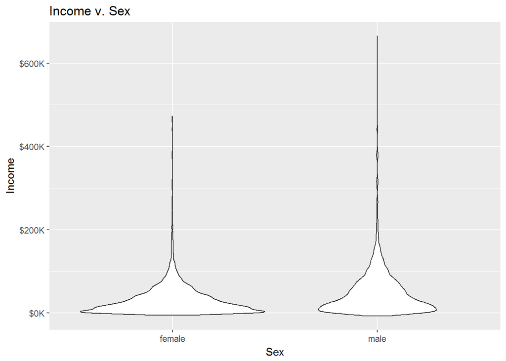

```r
# plots of different category
ppl %>%
  group_by(Sex) %>%
  ggplot(aes(Sex, income/1000)) +
  geom_violin() +
  scale_y_continuous(name="Income", labels = dollar_format(prefix = "$", suffix = "K")) +
  labs(title="Income v. Sex")
```

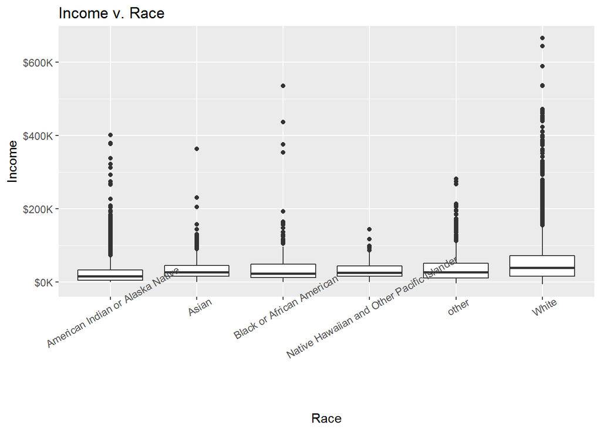

```r
ppl %>%
  group_by(Race) %>%
  ggplot(aes(Race, income/1000)) +
  geom_boxplot() +
  scale_y_continuous(name="Income", labels = dollar_format(prefix = "$", suffix = "K")) +
  labs(title="Income v. Race") +
  theme(axis.text.x = element_text(angle=30))
```

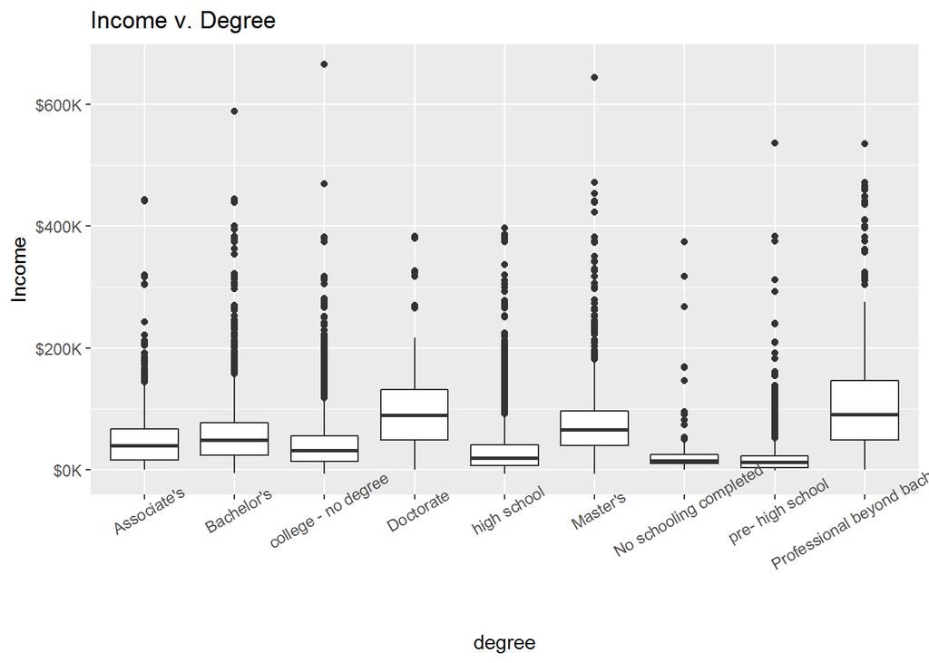

```r
ppl %>%
  group_by(degree) %>%
  ggplot(aes(degree, income/1000)) +
  geom_boxplot() +
  scale_y_continuous(name="Income", labels = dollar_format(prefix = "$", suffix = "K")) +
  labs(title="Income v. Degree") +
  theme(axis.text.x = element_text(angle=30))
```

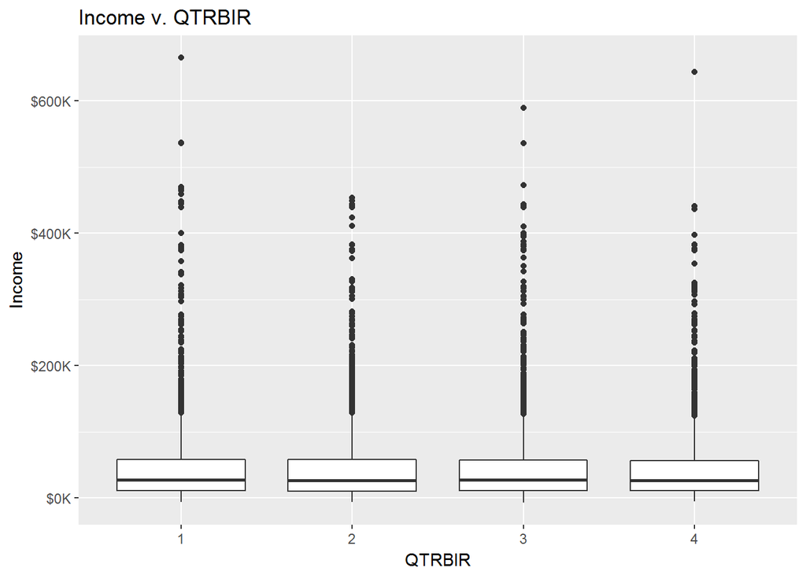

```r
ppl %>%
  group_by(QTRBIR) %>%
  ggplot(aes(QTRBIR, income/1000)) +
  geom_boxplot() +
  scale_y_continuous(name="Income", labels = dollar_format(prefix = "$", suffix = "K")) +
  labs(title="Income v. QTRBIR")
```

We see that professionals, doctors and masters earns more income on average to other groups. And there are some difference between the incomes recieved by male and female. Sadly, date of birth does not affect income. We will remove that from the dataframe.

```r
# :(
ppl <- ppl %>%
  select(-QTRBIR)
```

```r
# use random forest to generate model
# crossvalidation using random forest
rf_result <- createFolds(ppl$income, k=5) %>%
  # fit models and gather results
  purrr::imap(function(test_indices, fold_number) {
    # split into train and test for the fold
    train_df <- ppl %>%
      dplyr::slice(-test_indices)

    test_df <- ppl %>%
      dplyr::slice(test_indices)

    # fit the two models
    rf <- randomForest(income~., data=ppl, ntree=200)

    # gather results
    test_df %>%
      dplyr::select(observed_income = income) %>%
      mutate(fold=fold_number) %>%
      mutate(predicted_income = predict(rf, newdata=test_df))
  }) %>%
  # combine the five result data frames into one
  purrr::reduce(bind_rows)
rf_result
```

```
## # A tibble: 22,587 x 3
##    observed_income fold  predicted_income
##              <dbl> <chr>            <dbl>
##  1          14235. Fold1           40546.
##  2          17530. Fold1           11400.
##  3         305066. Fold1           49103.
##  4           3274. Fold1           12703.
##  5          68959. Fold1           69531.
##  6           1405. Fold1            8875.
##  7          42241. Fold1           28583.
##  8           2323. Fold1           12784.
##  9          71916. Fold1           88656.
## 10          60194. Fold1           70649.
## # ... with 22,577 more rows
```

We can plot the predicted income and observed incom togethere to see how well the model did.

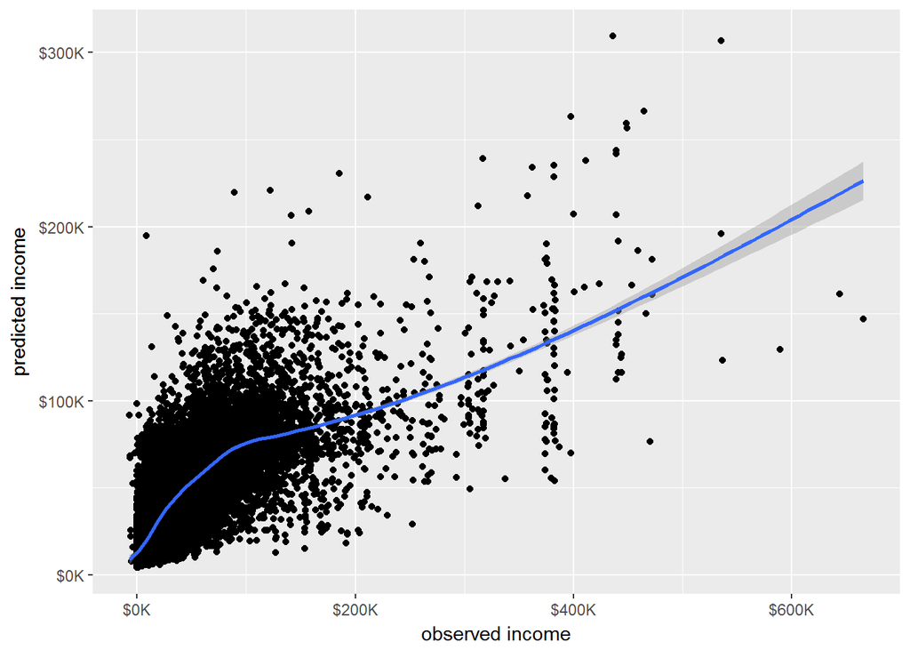

```r
rf_result %>%
  ggplot(aes(observed_income/1000, predicted_income/1000)) +
  geom_point()+
  geom_smooth() +
  scale_y_continuous(name="predicted income", labels = dollar_format(prefix = "$", suffix = "K"))+
  scale_x_continuous(name="observed income", labels = dollar_format(prefix = "$", suffix = "K"))
```

the line is roughly a y=x line around lower left corner and we see a lot of errors. This is because we are using discrete variables to predict continuous value. Above 200K, the model is predicting less than the observed income because there are too many outliers. Some people are making huge money “unreasonably”!  
Using the importance function, we can see how each factore are taken count into the model.

```r
rf <- randomForest(income~., data=ppl, ntree=200, importance = TRUE)
variable_importance <- importance(rf)
knitr::kable(head(round(variable_importance, digits=2)))
```

|  | %IncMSE | IncNodePurity |
| --- | --- | --- |
| Sex | 36.16 | 1.704100e+12 |
| hrs_Year | 60.93 | 1.116138e+13 |
| Race | 25.99 | 2.056514e+12 |
| degree | 28.74 | 3.991353e+12 |
| science_Degree | 9.57 | 1.364213e+12 |
| Nativity | 16.66 | 2.751110e+11 |

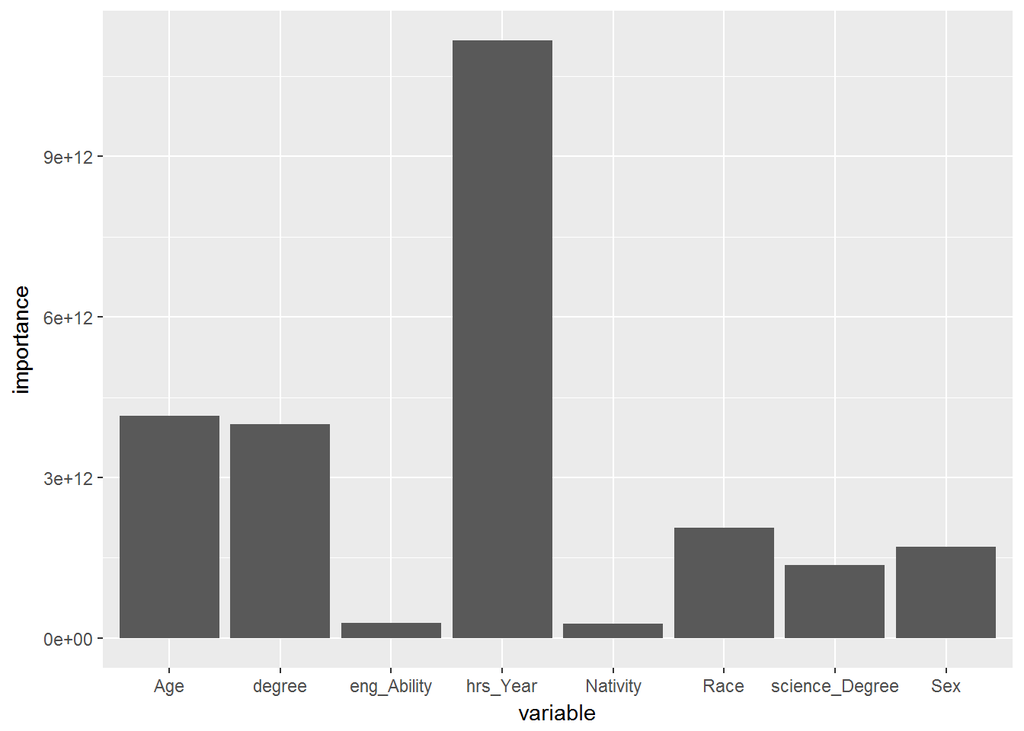

```r
v_imp <- variable_importance %>%
  as_data_frame()
v_imp$variable <- row.names(variable_importance)

v_imp %>%
  ggplot(aes(variable, IncNodePurity)) +
  geom_bar(stat = "identity") +
  scale_y_continuous(name="importance")
```

The graph suggests, work hours are highly related to income (unsuprising). It also suggests english ability is unrelavent to income as well as nativity. Age, race, degree, whether the degree is related to science or not and sex contribute to income. This suggests that given an input with these information, a person’s income can be predicted. Follow this toturial, you can generate a website to let students input their information and find out how much they are expecting to make after school!